# Problem Set 6

## **EECS225B Problem Set 6**

### Emaad Khwaja

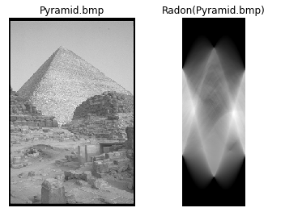

The filter parameter used by default in the iradon function is the ramp filter. It is a high-pass filter. This can affect the image reconstruction capabilities if the sample has a high degree of noise, as a high-pass filter will enhance this.  
The interpolation parameter changes the type of computed interpolation used. By default, linear interpolation is used. The tradeoff is the same as interpolation in any other contexts. More robust interpolation methods will yield higher quality reconstruction, but at the expense of computational efficiency.  
In ConvBack2.bmp, we reduce the number of θ samples by a factor of 2, and in ConvBack5, it is reduced by 5. We can see a global effect of reduced image quality when sampling less angles. This is because fewer sampling angles means the interpolation has less domain information to work with, leading to unnnecessary smoothing in the Fourier domain. We see more artifacting in the high frequency domain because there is a larger degree of interpolation occurring at the edges of the Fourier image when less angles are sampled, while the DC component is still fairly well represented.

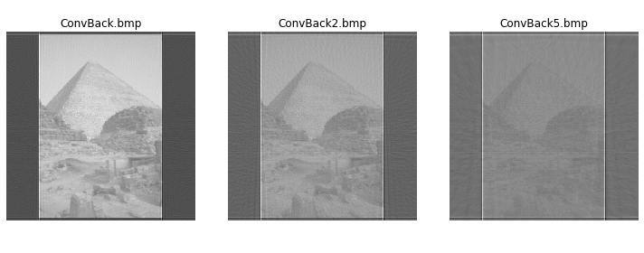

We can see that the polar reconstruction of the image is very similar to the original image. There are slight differences between this and the iradon reconstruction. In theory these should be identical because of the equivalency established through the Projection-Slice theorem. These differences are probably due to inconsistencies brought about by the nearest neighbor interpolation in the Fourier domain.

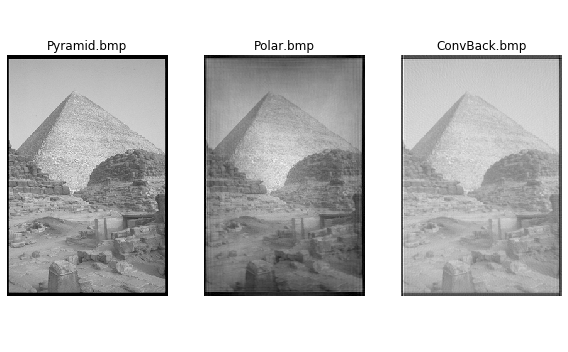